# Power Automate for health and care

Brendan Clarke, NHS Education for Scotland, brendan.clarke2@nhs.scot

08/08/2024

## Welcome

- this session is 🌶 - for beginners
- we’ll get going properly at 13.05
- if you can’t access the chat, you might need to join our Teams channel: [tinyurl.com/kindnetwork](https://teams.microsoft.com/l/team/19%3AQZ7-PbFVcziG2piHLt1_ifey3I2cwFL0yBuTSS8vVao1%40thread.tacv2/conversations?groupId=106d08f3-9026-40e2-b3c7-87cd87304d58&tenantId=10efe0bd-a030-4bca-809c-b5e6745e499a)
- you can find session materials at [tinyurl.com/kindtrp](https://nes-dew.github.io/KIND-training/)

## The KIND network

- a social learning space for staff working with **k**nowledge, **i**nformation, and **d**ata across health, social care, and housing in Scotland
- we offer social support, free training, mentoring, community events, …
- [Teams channel](https://teams.microsoft.com/l/team/19%3AQZ7-PbFVcziG2piHLt1_ifey3I2cwFL0yBuTSS8vVao1%40thread.tacv2/conversations?groupId=106d08f3-9026-40e2-b3c7-87cd87304d58&tenantId=10efe0bd-a030-4bca-809c-b5e6745e499a) / [mailing list](https://forms.office.com/pages/responsepage.aspx?id=veDvEDCgykuAnLXmdF5JmpopIZB9ynRJnrPUHVFccipURjM2NkZJUkhGOFlQRjQxRFhVUTgwT0UwVyQlQCN0PWcu)

## KIND training sessions

| Session | Date | Area | Level |
| --- | --- | --- | --- |
| Power automate for health and care | 13:00-14:00 Thu 8th August 2024 | Data | 🌶 :**beginner-level** |
| Relative, absolute, mixed, structured, and R1C1 references in Excel | 15:00-16:00 Thu 8th August 2024 | Excel | 🌶🌶 : **intermediate-level** |
| Neural nets made ridiculously simple | 13:00-14:00 Mon 12th August 2024 | AI/ML | 🌶 :**beginner-level** |
| Hacker Stats (AKA Resampling Methods) | 14:00-15:00 Wed 14th August 2024 | R | 🌶🌶🌶 : **advanced-level** |

## Session outline

- a warning
- an introduction
- scope of the possible
- three example tasks
- free play

## A word of warning

**Warning**

Do not use Power Automate for anything unless you’re absolutely sure that your organisational policies permit it

- many boards and orgs have serious information governance and information security objections to Power Automate
  - automation tools are an excellent way to break your data
  - they’re also an excellent way to compromise its integrity/security
  - especially true if you’re thinking about automating processes with sensitive information
  - if in any doubt, speak to your IG/Caldicott/information security colleagues before setting to work

## Quick introduction to Power Automate

- [Power Automate](https://en.wikipedia.org/wiki/Microsoft_Power_Automate) is a set of low-code automation tools
- allows users to automate tasks
- lots of options
  - web and [desktop versions](https://learn.microsoft.com/en-us/power-automate/desktop-flows/install)
  - several [different subscription levels](https://www.microsoft.com/en-us/power-platform/products/power-automate/#Pricing)
  - hundreds of add-ons

## Subset an Excel file

- you’ll need a sample data file - I used [this open data about council assets from Falkirk](https://opendata.scot/datasets/falkirk+council-council+asset+register+-+falkirk/)
- I coverted the data to a table, then saved the workbook to OneDrive
- `New flow > Instant cloud flow`

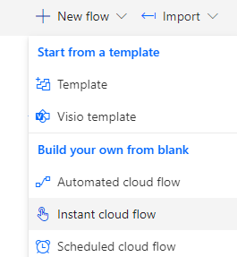

## Subset an Excel file

- `Manually trigger a flow`

[figure not shown]

## Subset an Excel file

- Add a step

[figure not shown]

## Subset an Excel file

- `Excel online > List rows present in a table` and populate

[figure not shown]

## Subset an Excel file

- there are several ways we could subset the data

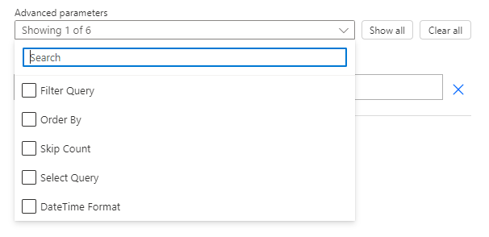

## Subset an Excel file

- we’ll demonstrate by taking the first 20 rows

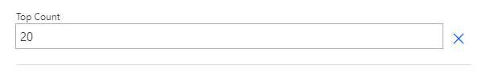

## Subset an Excel file

- `Create csv table`

[figure not shown]

## Subset an Excel file

- `Create file`

[figure not shown]

## Microsoft Forms to Teams

- here’s an overview

[figure not shown]

## Microsoft Forms to Teams

- create a simple form (ours is at https://forms.office.com/e/8Zds2aTS5c)

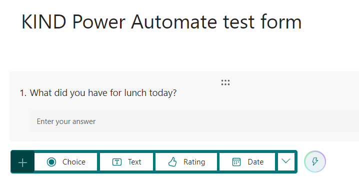

## Microsoft Forms to Teams

- grab the form id

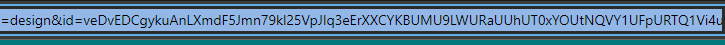

- create an `Build an automated cloud flow` -

[figure not shown]

## Microsoft Forms to Teams

- Enter your form ID

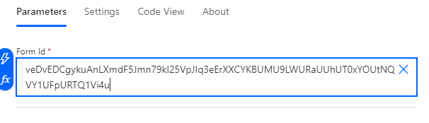

  (veDvEDCgykuAnLXmdF5Jmn79kl25VpJIq3eErXXCYKBUMU9LWURaUUhUT0xYOUtNQVY1UFpURTQ1Vi4u)

## Microsoft Forms to Teams

- `Get response details`

[figure not shown]

## Microsoft Forms to Teams

- Populate with the form and step details

[figure not shown]

## Microsoft Forms to Teams

- `Post message in a chat or channel`

[figure not shown]

## Excel workbook to mailing list

- here’s an overview

[figure not shown]

## Excel workbook to mailing list

- start with a simple .xlsx. Again, that will need to be on Sharepoint or Onedrive

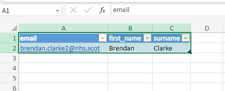

## Excel workbook to mailing list

- `List rows present in a table`

[figure not shown]

## Excel workbook to mailing list

- `Apply to each`

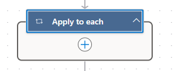

## Excel workbook to mailing list

- `Send an email notification (V3)` nested inside the `Apply to each`

[figure not shown]

## Excel workbook to mailing list

- add the expression `items('For_each')?['email']`

[figure not shown]

## Excel workbook to mailing list

- enjoy the result

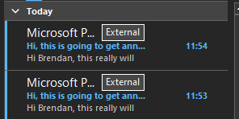

## Feedback and resources

- please can I ask for some feedback - takes less than a minute, completely anonymous, helps people like you find the right training for them

| Session | Date | Area | Level |
| --- | --- | --- | --- |
| Power automate for health and care | 13:00-14:00 Thu 8th August 2024 | Data | 🌶 :**beginner-level** |
| Relative, absolute, mixed, structured, and R1C1 references in Excel | 15:00-16:00 Thu 8th August 2024 | Excel | 🌶🌶 : **intermediate-level** |
| Neural nets made ridiculously simple | 13:00-14:00 Mon 12th August 2024 | AI/ML | 🌶 :**beginner-level** |
| Hacker Stats (AKA Resampling Methods) | 14:00-15:00 Wed 14th August 2024 | R | 🌶🌶🌶 : **advanced-level** |